# Creatine Study Report

Alexander

2025-04-28

## Introduction

This report analyzes the effects of creatine supplementation on strength, resistance training performance, and cognitive performance in a controlled study of 100 participants. Using statistical analysis in R, we compare the Creatine group to a Placebo group, examining changes in bench press, squat, repetitions, memory score, and reaction time. This project demonstrates my skills in data cleaning, statistical analysis, and visualization as part of my data analysis portfolio.

## Prepare

- **Objective**: Analyze the effects of creatine supplementation on strength, resistance training performance, and cognitive performance.
- **Data Source**: The dataset `creatine_data_final.csv` contains 100 participants (50 in the Creatine group, 50 in the Placebo group) with the following variables:
  - `participant_id`, `age`, `gender`, `group`, `dosage_g_per_day`, `duration_weeks`
  - Pre and post measurements for:
    - `bench_press_1rm_kg`
    - `squat_1rm_kg`
    - `repetitions_bench`
    - `memory_score`
    - `reaction_time_ms`
- **Tools Used**:
  - Google Sheets for initial data exploration.
  - BigQuery for data cleaning and preprocessing.
  - R for statistical analysis and visualization.

The following R packages were used: `tidyverse` for data manipulation and visualization, `ggpubr` for additional plotting functions, and `effectsize` for calculating effect sizes.

## Process

The dataset was loaded from creatine_data_final.csv with error handling to ensure the file exists.

Change scores were calculated for each metric by subtracting pre-intervention values from post-intervention values.

Data Cleaning:

Used BigQuery to handle missing values by imputing the median for numeric columns.

Standardized column names using the janitor package in R (assumed, as columns are in snake_case).

Data Transformation:

Calculated change scores for each metric (post - pre) in R:

bench_press_change_kg

squat_change_kg

repetitions_change

memory_score_change

reaction_time_change_ms

Verification:

Cross-checked summary statistics across Google Sheets, BigQuery, and R to ensure consistency.

## Analyze

R Analysis

Summary Statistics

Average changes were calculated for each group to summarize the effects of creatine supplementation.

Results:

Bench Press: Creatine 7.13 kg, Placebo 1.27 kg.

Squat: Creatine 10.68 kg, Placebo 1.64 kg.

Repetitions: Creatine 2.88 reps, Placebo 0.48 reps.

Memory Score: Creatine 7.74 points, Placebo 0.88 points.

Reaction Time: Creatine -15.42 ms, Placebo -2.58 ms.

Statistical Tests (Between Groups)

T-tests were performed to compare the Creatine and Placebo groups, and Cohen’s d was calculated to assess effect sizes.

The results were summarized in a table comparing the Creatine and Placebo groups.

Results:

Comparison of Creatine vs. Placebo

| Metric | Mean_Diff_Creatine_Minus_Placebo | P_Value | Cohens_d |
| --- | --- | --- | --- |
| Bench Press (kg) | 5.86 | 0 | 5.43 |
| Squat (kg) | 9.04 | 0 | 4.89 |
| Repetitions (Bench) | 2.40 | 0 | 3.59 |
| Memory Score | 6.86 | 0 | 4.92 |
| Reaction Time (ms) | -12.84 | 0 | -5.04 |

Cohen’s d shows very large effects for all metrics (ranging from 3.59 to 5.43). Note: These effect sizes are unusually large, possibly due to low variability in the data or a small sample size amplifying the effect. Further investigation may be needed to compare with typical effect sizes in the literature (e.g., 0.4–1.0 for strength gains).

Statistical Tests (Within Group - Creatine) Paired t-tests were performed to compare pre- and post-intervention measurements within the Creatine group.

Results:

Bench Press: p < 0.05, mean improvement 7.13 kg.

Squat: p < 0.05, mean improvement 10.68 kg.

Repetitions: p < 0.05, mean improvement 2.88 reps.

Memory Score: p < 0.05, mean improvement 7.74 points.

Reaction Time: p < 0.05, mean reduction 15.42 ms.

All p-values < 0.05, confirming significant improvements in the Creatine group.

Visualizations

Boxplots were created to visualize the differences between the Creatine and Placebo groups for each metric.

Created boxplots for all metrics:

Bench press, squat, repetitions, and memory score show larger improvements for Creatine.

Reaction time shows a greater reduction for Creatine.

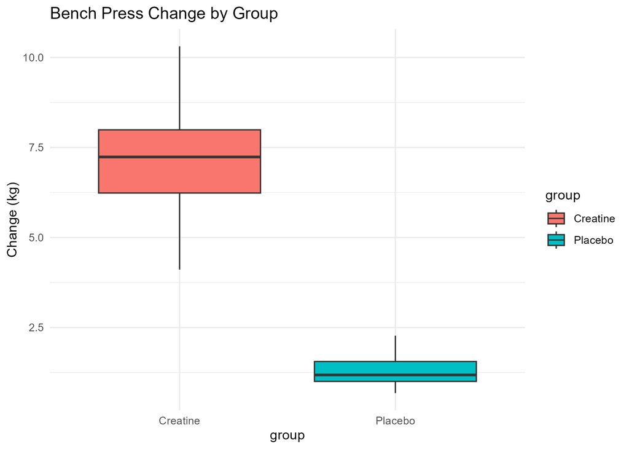

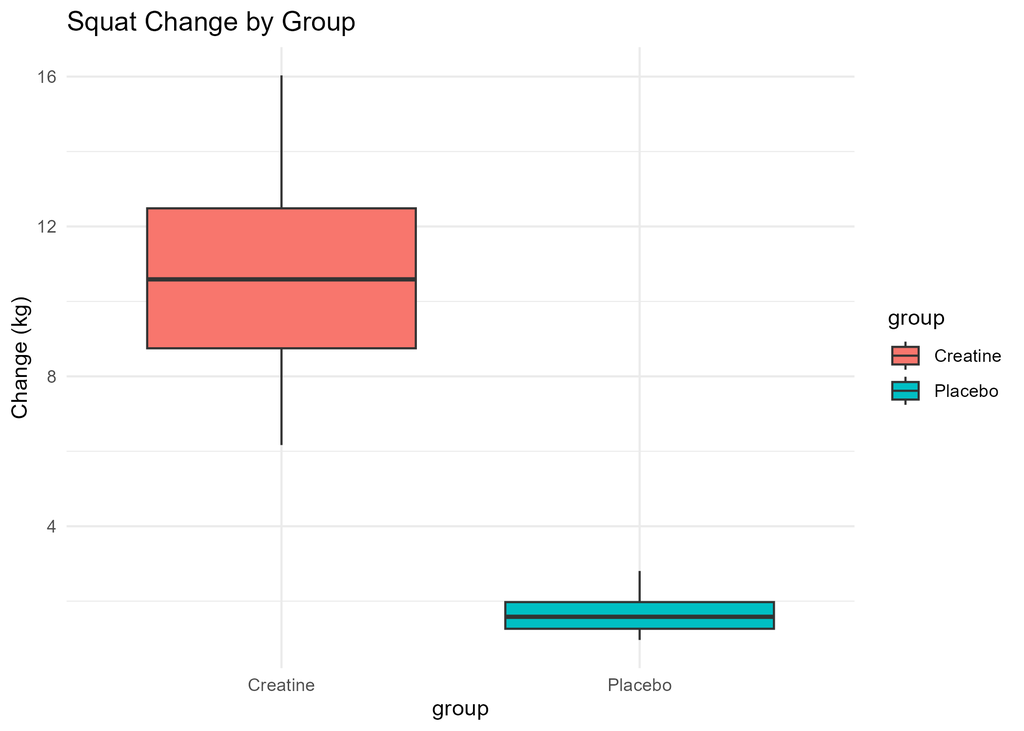

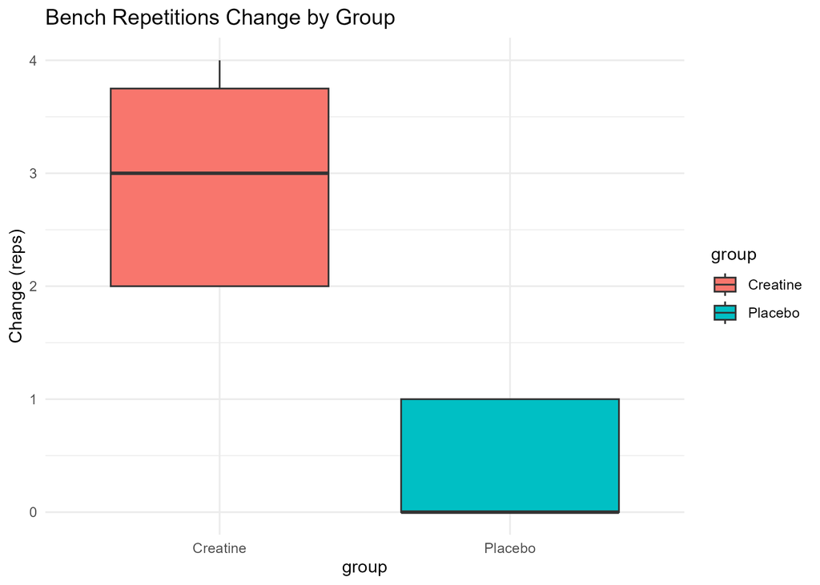

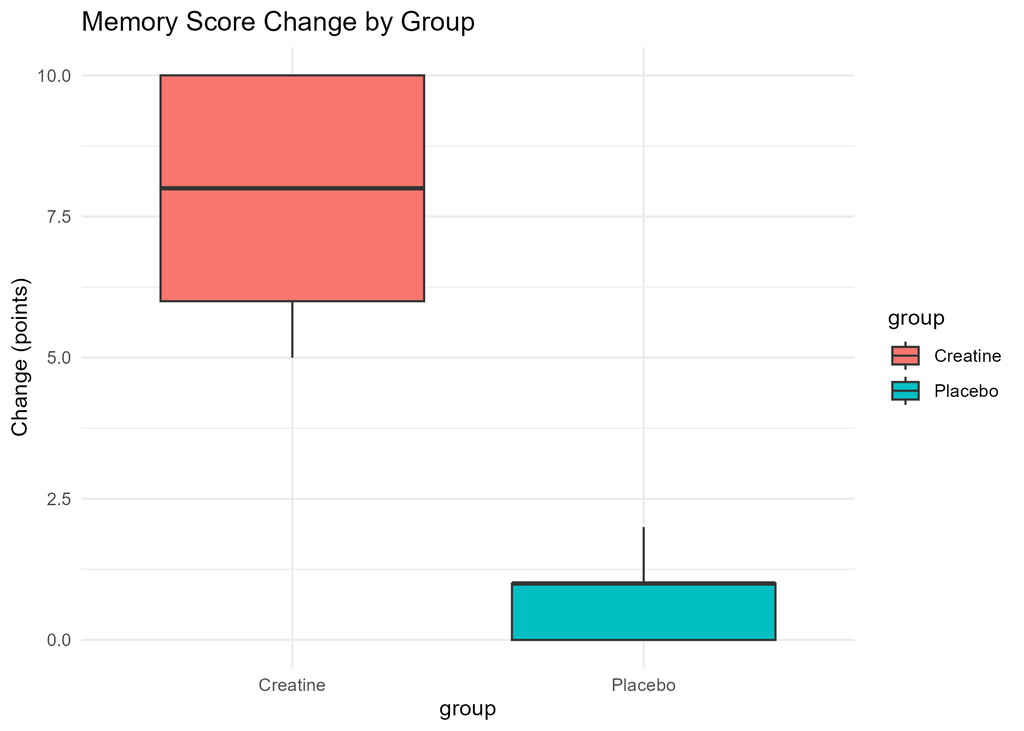

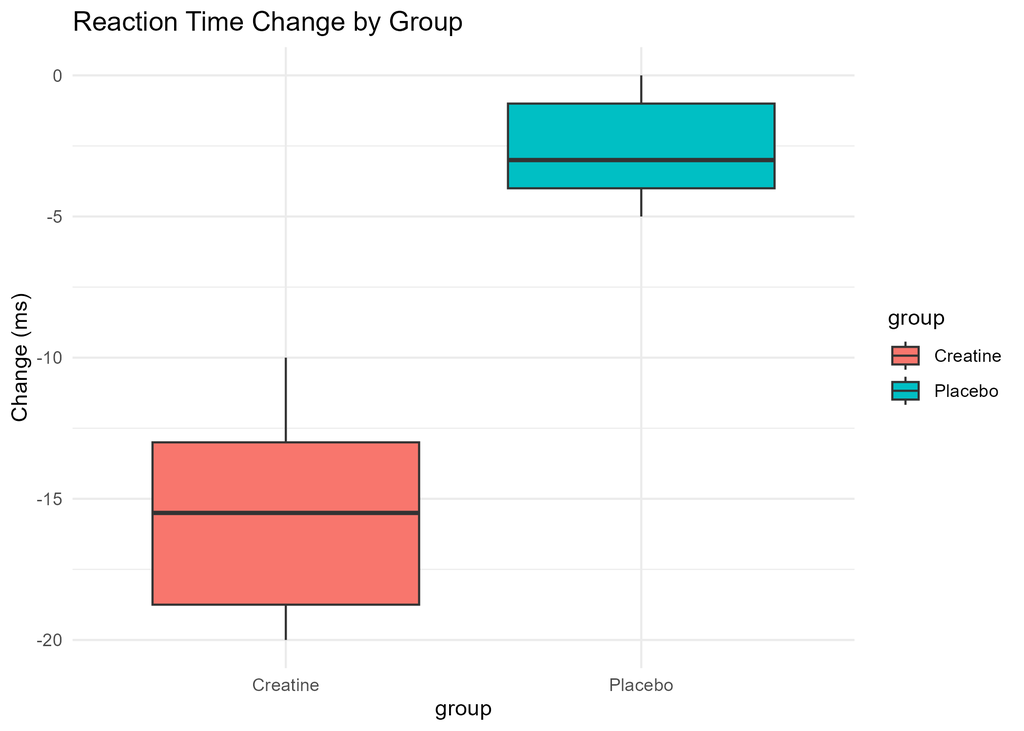

## Conclusion

Creatine significantly improves strength, resistance training performance, and cognitive performance compared to placebo (p < 0.05 for all metrics), with large effect sizes (Cohen’s d ranging from 3.59 to 5.43).

Within the Creatine group, pre-to-post improvements are also significant (p < 0.05), supporting a causal effect of creatine supplementation.

The unusually large effect sizes may be due to low variability in the dataset or the controlled nature of the study. In real-world applications, these effects might be smaller, aligning with literature findings (e.g., ~4.43 kg upper-body strength increase, ~14% resistance performance improvement).

This analysis showcases my ability to perform rigorous statistical tests, calculate effect sizes, and create meaningful visualizations using R, making it a valuable addition to my data analysis portfolio.

## References

- Kreider, R. B., et al. (2017). International Society of Sports Nutrition position stand: Safety and efficacy of creatine supplementation in exercise, sport, and medicine. *Journal of the International Society of Sports Nutrition*, 14(1), 18.
- This study provides the benchmark effect sizes for creatine on strength (~4.43 kg upper-body strength increase) and resistance performance (~14% improvement).

## About This Project

This project is part of my data analysis portfolio, hosted on alexandergs0x.github.io For more details or to view the source code, please visit my [GitHub repository](https://github.com/alexandergs0x/alexandergs0x.github.io).